# Assignment: Data Wrangling

### `! git clone https://github.com/ds4e/wrangling`

### Do Q1 and Q2, and either Q3 or Q4, for a total of 3 questions.

**Q1.** This question provides some practice cleaning variables which have common problems.

1. Numeric variable: For `./data/airbnb_hw.csv`, clean the `Price` variable as well as you can, and explain the choices you make. How many missing values do you end up with? (Hint: What happens to the formatting when a price goes over 999 dollars, say from 675 to 1,112?)
2. Categorical variable: For the Minnesota police use of for data, `./data/mn_police_use_of_force.csv`, clean the `subject_injury` variable, handling the NA's; this gives a value `Yes` when a person was injured by police, and `No` when no injury occurred. What proportion of the values are missing? Is this a concern? Cross-tabulate your cleaned `subject_injury` variable with the `force_type` variable. Are there any patterns regarding when the data are missing?
3. Dummy variable: For the pretrial data covered in the lecture, clean the `WhetherDefendantWasReleasedPretrial` variable as well as you can, and, in particular, replace missing values with `np.nan`.
4. Missing values, not at random: For the pretrial data covered in the lecture, clean the `ImposedSentenceAllChargeInContactEvent` variable as well as you can, and explain the choices you make. (Hint: Look at the `SentenceTypeAllChargesAtConvictionInContactEvent` variable.)

```python
import pandas as pd
import numpy as np
import seaborn as sns
```

```python
airbnb_data = pd.read_csv('./airbnb_hw.csv')

shark_data = pd.read_csv('./sharks.csv')
```

```python
airbnb_data.head(15)
```

|  | Host Id | Host Since | Name | Neighbourhood | Property Type | Review Scores Rating (bin) | Room Type | Zipcode | Beds | Number of Records | Number Of Reviews | Price | Review Scores Rating |
| --- | --- | --- | --- | --- | --- | --- | --- | --- | --- | --- | --- | --- | --- |
| 0 | 5162530 | NaN | 1 Bedroom in Prime Williamsburg | Brooklyn | Apartment | NaN | Entire home/apt | 11249.0 | 1.0 | 1 | 0 | 145 | NaN |
| 1 | 33134899 | NaN | Sunny, Private room in Bushwick | Brooklyn | Apartment | NaN | Private room | 11206.0 | 1.0 | 1 | 1 | 37 | NaN |
| 2 | 39608626 | NaN | Sunny Room in Harlem | Manhattan | Apartment | NaN | Private room | 10032.0 | 1.0 | 1 | 1 | 28 | NaN |
| 3 | 500 | 6/26/2008 | Gorgeous 1 BR with Private Balcony | Manhattan | Apartment | NaN | Entire home/apt | 10024.0 | 3.0 | 1 | 0 | 199 | NaN |
| 4 | 500 | 6/26/2008 | Trendy Times Square Loft | Manhattan | Apartment | 95.0 | Private room | 10036.0 | 3.0 | 1 | 39 | 549 | 96.0 |
| 5 | 1039 | 7/25/2008 | Big Greenpoint 1BD w/ Skyline View | Brooklyn | Apartment | 100.0 | Entire home/apt | 11222.0 | 1.0 | 1 | 4 | 149 | 100.0 |
| 6 | 1783 | 8/12/2008 | Amazing Also | Manhattan | Apartment | 100.0 | Entire home/apt | 10004.0 | 1.0 | 1 | 9 | 250 | 100.0 |
| 7 | 2078 | 8/15/2008 | Colorful, quiet, & near the subway! | Brooklyn | Apartment | 90.0 | Private room | 11201.0 | 1.0 | 1 | 80 | 90 | 94.0 |
| 8 | 2339 | 8/20/2008 | East Village Cocoon: 2 Bedroom Flat | Manhattan | Apartment | 90.0 | Entire home/apt | 10009.0 | 2.0 | 1 | 95 | 270 | 90.0 |
| 9 | 2339 | 8/20/2008 | Lovely 2 Bedroom East Village Nest | Manhattan | Apartment | 95.0 | Entire home/apt | 10009.0 | 2.0 | 1 | 23 | 290 | 96.0 |
| 10 | 2571 | 8/27/2008 | THE PUTNAM | Brooklyn | Apartment | 95.0 | Entire home/apt | 11221.0 | 2.0 | 1 | 14 | 170 | 98.0 |
| 11 | 2758 | 9/6/2008 | Stay at Chez Chic budget room #1 | Manhattan | Apartment | 90.0 | Private room | 10026.0 | 2.0 | 1 | 120 | 59 | 93.0 |
| 12 | 2758 | 9/6/2008 | Stay at Chez Chic budget Room #2 | Manhattan | Apartment | 90.0 | Private room | 10026.0 | 2.0 | 1 | 81 | 49 | 91.0 |
| 13 | 2787 | 9/7/2008 | Renovated and spacious townhome | Brooklyn | House | NaN | Private room | 11223.0 | 1.0 | 1 | 0 | 68 | NaN |
| 14 | 2845 | 9/9/2008 | Midtown Castle | Manhattan | Apartment | 95.0 | Entire home/apt | 10018.0 | 1.0 | 1 | 17 | 285 | 97.0 |

```python
price_data = airbnb_data['Price']
price_data.unique()
```

```
array(['145', '37', '28', '199', '549', '149', '250', '90', '270', '290',
       '170', '59', '49', '68', '285', '75', '100', '150', '700', '125',
       '175', '40', '89', '95', '99', '499', '120', '79', '110', '180',
       '143', '230', '350', '135', '85', '60', '70', '55', '44', '200',
       '165', '115', '74', '84', '129', '50', '185', '80', '190', '140',
       '45', '65', '225', '600', '109', '1,990', '73', '240', '72', '105',
       '155', '160', '42', '132', '117', '295', '280', '159', '107', '69',
       '239', '220', '399', '130', '375', '585', '275', '139', '260',
       '35', '133', '300', '289', '179', '98', '195', '29', '27', '39',
       '249', '192', '142', '169', '1,000', '131', '138', '113', '122',
       '329', '101', '475', '238', '272', '308', '126', '235', '315',
       '248', '128', '56', '207', '450', '215', '210', '385', '445',
       '136', '247', '118', '77', '76', '92', '198', '205', '299', '222',
       '245', '104', '153', '349', '114', '320', '292', '226', '420',
       '500', '325', '307', '78', '265', '108', '123', '189', '32', '58',
       '86', '219', '800', '335', '63', '229', '425', '67', '87', '1,200',
       '158', '650', '234', '310', '695', '400', '166', '119', '62',
       '168', '340', '479', '43', '395', '144', '52', '47', '529', '187',
       '209', '233', '82', '269', '163', '172', '305', '156', '550',
       '435', '137', '124', '48', '279', '330', '5,000', '134', '378',
       '97', '277', '64', '193', '147', '186', '264', '30', '3,000',
       '112', '94', '379', '57', '415', '236', '410', '214', '88', '66',
       '71', '171', '157', '545', '1,500', '83', '96', '1,800', '81',
       '188', '380', '255', '505', '54', '33', '174', '93', '740', '640',
       '1,300', '440', '599', '357', '1,239', '495', '127', '5,999',
       '178', '348', '152', '242', '183', '253', '750', '259', '365',
       '273', '197', '397', '103', '389', '355', '559', '38', '203',
       '999', '141', '162', '333', '698', '46', '360', '895', '10', '41',
       '206', '281', '449', '388', '212', '102', '201', '2,750', '4,750',
       '432', '675', '167', '390', '298', '339', '194', '302', '211',
       '595', '191', '53', '361', '480', '8,000', '4,500', '459', '997',
       '345', '216', '218', '111', '735', '276', '91', '490', '850',
       '398', '36', '775', '267', '625', '336', '2,500', '176', '725',
       '3,750', '469', '106', '460', '287', '575', '227', '263', '25',
       '228', '208', '177', '880', '148', '116', '685', '470', '217',
       '164', '61', '645', '699', '405', '252', '319', '268', '419',
       '343', '525', '311', '840', '154', '294', '950', '409', '184',
       '257', '204', '241', '2,000', '412', '121', '288', '196', '900',
       '647', '524', '1,750', '309', '510', '1,495', '1,700', '799',
       '383', '372', '492', '327', '1,999', '656', '224', '173', '875',
       '1,170', '795', '690', '146', '465', '1,100', '151', '274', '429',
       '825', '282', '256', '1,111', '620', '271', '161', '51', '855',
       '579', '1,174', '430', '20', '899', '649', '485', '181', '455',
       '4,000', '243', '342', '590', '560', '374', '437', '232', '359',
       '985', '31', '244', '254', '723', '237', '428', '370', '34',
       '1,400', '580', '2,520', '221', '749', '1,600', '2,695', '306',
       '202', '680', '570', '520', '223', '2,295', '213', '1,065', '346',
       '24', '286', '296', '266', '26', '995', '1,368', '393', '182',
       '635', '258', '780', '589', '347', '1,250', '1,350', '446',
       '3,200', '1,050', '1,650', '1,550', '975', '323', '6,500', '2,499',
       '1,850', '2,250', '715', '461', '540', '356', '439', '384', '569',
       '1,900', '22', '785', '626', '830', '318', '444', '321', '401',
       '1,499', '888', '369', '770', '386', '366', '344', '630', '313',
       '597', '262', '509', '10,000', '278', '312', '789', '1,195', '422',
       '21', '765', '3,500', '945', '326', '3,100', '2,486', '3,390',
       '1,356', '2,599', '472', '454', '328', '396', '291'], dtype=object)
```

```python
price = price_data.str.replace(',','')
price = pd.to_numeric(price,errors='coerce')
print( price.unique() , '\n')
print( 'Total missing: ', sum( price.isnull() ) )
```

```
[  145    37    28   199   549   149   250    90   270   290   170    59
    49    68   285    75   100   150   700   125   175    40    89    95
    99   499   120    79   110   180   143   230   350   135    85    60
    70    55    44   200   165   115    74    84   129    50   185    80
   190   140    45    65   225   600   109  1990    73   240    72   105
   155   160    42   132   117   295   280   159   107    69   239   220
   399   130   375   585   275   139   260    35   133   300   289   179
    98   195    29    27    39   249   192   142   169  1000   131   138
   113   122   329   101   475   238   272   308   126   235   315   248
   128    56   207   450   215   210   385   445   136   247   118    77
    76    92   198   205   299   222   245   104   153   349   114   320
   292   226   420   500   325   307    78   265   108   123   189    32
    58    86   219   800   335    63   229   425    67    87  1200   158
   650   234   310   695   400   166   119    62   168   340   479    43
   395   144    52    47   529   187   209   233    82   269   163   172
```

[output cut: 30 more lines]

```python
police_data = pd.read_csv('./minnesota.csv')
police_data.head(15)
```

|  | response_datetime | problem | is_911_call | primary_offense | subject_injury | force_type | force_type_action | race | sex | age | type_resistance | precinct | neighborhood |
| --- | --- | --- | --- | --- | --- | --- | --- | --- | --- | --- | --- | --- | --- |
| 0 | 2016/01/01 00:47:36 | Assault in Progress | Yes | DASLT1 | NaN | Bodily Force | Body Weight to Pin | Black | Male | 20.0 | Tensed | 1 | Downtown East |
| 1 | 2016/01/01 02:19:34 | Fight | No | DISCON | NaN | Chemical Irritant | Personal Mace | Black | Female | 27.0 | Verbal Non-Compliance | 1 | Downtown West |
| 2 | 2016/01/01 02:19:34 | Fight | No | DISCON | NaN | Chemical Irritant | Personal Mace | White | Female | 23.0 | Verbal Non-Compliance | 1 | Downtown West |
| 3 | 2016/01/01 02:28:48 | Fight | No | PRIORI | NaN | Chemical Irritant | Crowd Control Mace | Black | Male | 20.0 | Commission of Crime | 1 | Downtown West |
| 4 | 2016/01/01 02:28:48 | Fight | No | PRIORI | NaN | Chemical Irritant | Crowd Control Mace | Black | Male | 20.0 | Commission of Crime | 1 | Downtown West |
| 5 | 2016/01/01 02:28:48 | Fight | No | PRIORI | NaN | Chemical Irritant | Crowd Control Mace | Black | Male | 20.0 | Commission of Crime | 1 | Downtown West |
| 6 | 2016/01/01 02:28:48 | Fight | No | PRIORI | NaN | Chemical Irritant | Crowd Control Mace | Black | Female | 20.0 | Commission of Crime | 1 | Downtown West |
| 7 | 2016/01/01 02:28:48 | Fight | No | PRIORI | NaN | Chemical Irritant | Crowd Control Mace | Black | Male | 20.0 | Commission of Crime | 1 | Downtown West |
| 8 | 2016/01/01 02:28:48 | Fight | No | PRIORI | NaN | Chemical Irritant | Crowd Control Mace | Black | Male | 20.0 | Unspecified | 1 | Downtown West |
| 9 | 2016/01/01 02:38:23 | Fight | No | DISCON | No | Chemical Irritant | Crowd Control Mace | Black | Male | 18.0 | commission of crime | 1 | Downtown West |
| 10 | 2016/01/01 02:38:23 | Fight | No | DISCON | No | Chemical Irritant | Chemical Munitions | Black | Male | 18.0 | commission of crime | 1 | Downtown West |
| 11 | 2016/01/01 02:39:47 | Suspicious Person | No | DISCON | Yes | Bodily Force | Body Weight to Pin | Black | Male | 21.0 | Tensed | 5 | Lowry Hill East |
| 12 | 2016/01/01 02:39:47 | Suspicious Person | No | DISCON | Yes | Bodily Force | Joint Lock | Black | Male | 21.0 | Tensed | 5 | Lowry Hill East |
| 13 | 2016/01/01 02:39:47 | Suspicious Person | No | DISCON | Yes | Bodily Force | Body Weight to Pin | Black | Male | 21.0 | Tensed | 5 | Lowry Hill East |
| 14 | 2016/01/01 03:11:20 | Chase on Foot | No | FLEE | No | Bodily Force | Body Weight to Pin | Black | Male | 17.0 | Fled in Vehicle | 3 | Ventura Village |

```python
df = pd.DataFrame(police_data)
print(df.columns)
nan_count = df['subject_injury'].isna().sum()
print(nan_count)
df['subject_injury'] = df['subject_injury'].map({'Yes': 1, 'No': 0})
total_count = df['subject_injury'].sum()
print(f"Total injuries: {total_count}")
proportion = nan_count / (total_count + nan_count)
print(proportion)
```

```
Index(['response_datetime', 'problem', 'is_911_call', 'primary_offense',
       'subject_injury', 'force_type', 'force_type_action', 'race', 'sex',
       'age', 'type_resistance', 'precinct', 'neighborhood'],
      dtype='object')
9848
Total injuries: 1631.0
0.8579144524784389
```

```python
df['subject_injury'] = pd.to_numeric(df['subject_injury'], errors='coerce')  # Convert non-numeric values to NaN
df['subject_injury'].fillna(0, inplace=True)  # Replace NaNs with 0 if needed
```

```python
cross_tab = pd.crosstab(df['subject_injury'], df['force_type'])
print(cross_tab)
```

```
force_type      Baton  Bodily Force  Chemical Irritant  Firearm  \
subject_injury
0.0                 2          8144               1552        2
1.0                 2          1286                 41        0

force_type      Gun Point Display  Improvised Weapon  Less Lethal  \
subject_injury
0.0                            60                108           87
1.0                            44                 40            0

force_type      Less Lethal Projectile  Maximal Restraint Technique  \
subject_injury
0.0                                  1                          170
1.0                                  2                            0

force_type      Police K9 Bite  Taser
subject_injury
0.0                         33   1135
1.0                         44    172
```

```python
print(df.columns)
total_count = df['subject_injury'].sum()
print(total_count)
```

```
Index(['response_datetime', 'problem', 'is_911_call', 'primary_offense',
       'subject_injury', 'force_type', 'force_type_action', 'race', 'sex',
       'age', 'type_resistance', 'precinct', 'neighborhood'],
      dtype='object')
1631.0
```

```python
url = 'http://www.vcsc.virginia.gov/pretrialdataproject/October%202017%20Cohort_Virginia%20Pretrial%20Data%20Project_Deidentified%20FINAL%20Update_10272021.csv'
df = pd.read_csv(url,low_memory=False)
```

```python
df.head()
```

|  | InternalStudyID | REQ_REC# | Defendant_Sex | Defendant_Race | Defendant_BirthYear | Defendant_Age | Defendant_AgeGroup | Defendant_AgeatCurrentArrest | Defendant_AttorneyTypeAtCaseClosure | Defendant_IndigencyStatus | ... | NewFelonySexualAssaultArrest_OffDate | NewFelonySexualAssaultArrest_ArrestDate | NewFelonySexualAssaultArrest_DaysBetweenContactEventandOffDate | NewFelonySexualAssaultArrest_DaysBetweenOffDateandArrestDate | NewFelonySexualAssaultArrest_DaysBetweenReleaseDateandOffDate | NewFelonySexualAssaultArrest_Disposition | Intertnalindicator_ReasonforExcludingFromFollowUpAnalysis | CriminalHistoryRecordsReturnedorCMSRecordsFoundforIndividual | DispRecordFoundforChargesinOct2017Contact_Atleast1dispfound | CrimeCommission2021ReportClassificationofDefendants |
| --- | --- | --- | --- | --- | --- | --- | --- | --- | --- | --- | --- | --- | --- | --- | --- | --- | --- | --- | --- | --- | --- |
| 0 | ADI00001 | 1 | M | W | 1986 | 31 | 3 | 31 | 99 | 99 | ... |  |  |  | 999 | 999 |  | 4 | 1 | 0 | Defendant could not be classified or tracked d... |
| 1 | ADI00007 | 3 | M | B | 1956 | 60 | 6 | 60 | 9 | 9 | ... |  |  |  | 999 | 999 |  | 5 | 1 | 1 | Defendant Detained Entire Pre-Trial Period_Und... |
| 2 | ADI00008 | 4 | M | W | 1990 | 27 | 3 | 27 | 9 | 9 | ... |  |  |  | 999 | 999 |  | 5 | 1 | 1 | Defendant Detained Entire Pre-Trial Period_Und... |
| 3 | CDI00036 | 6 | M | B | 1989 | 27 | 3 | 27 | 0 | 0 | ... |  |  |  | 999 | 999 |  | 5 | 1 | 1 | Defendant Detained Entire Pre-Trial Period_Und... |
| 4 | CDI00038 | 7 | F | W | 1988 | 28 | 3 | 28 | 0 | 0 | ... |  |  |  | 999 | 999 |  | 0 | 1 | 1 | New criminal offense punishable by incarcerati... |

5 rows × 709 columns

```python
df['WhetherDefendantWasReleasedPretrial'] = df['WhetherDefendantWasReleasedPretrial'].replace(
    ['unknown', None, ''], np.nan)

#This replaces missing values with np.nan
```

```python
df['WhetherDefendantWasReleasedPretrial'].value_counts()
```

```
WhetherDefendantWasReleasedPretrial
1    19154
0     3801
9       31
Name: count, dtype: int64
```

```python
df.groupby('WhetherDefendantWasReleasedPretrial')['ImposedSentenceAllChargeInContactEvent'].describe()
```

| WhetherDefendantWasReleasedPretrial | count | unique | top | freq |
| --- | --- | --- | --- | --- |
| 0 | 3801 | 352 |  | 1047 |
| 1 | 19154 | 279 |  | 7989 |
| 9 | 31 | 10 |  | 17 |

These numbers reveal that True and False are not assigned to 0 and 1, but three numbers. The next line of code assigns 1 to True boolean values and 0 to False boolean values, which effectively eliminates the 9.

```python
df['WhetherDefendantWasReleasedPretrial'] = df['WhetherDefendantWasReleasedPretrial'].apply(lambda x: 1 if x == True else 0)
```

```python
df.groupby('WhetherDefendantWasReleasedPretrial')['ImposedSentenceAllChargeInContactEvent'].describe()
```

| WhetherDefendantWasReleasedPretrial | count | unique | top | freq |
| --- | --- | --- | --- | --- |
| 0 | 3832 | 352 |  | 1064 |
| 1 | 19154 | 279 |  | 7989 |

```python
df['SentenceTypeAllChargesAtConvictionInContactEvent'].unique()
df['SentenceTypeAllChargesAtConvictionInContactEvent'].value_counts()
```

```
SentenceTypeAllChargesAtConvictionInContactEvent
4    8779
0    8720
1    4299
2     914
9     274
Name: count, dtype: int64
```

```python
df['ImposedSentenceAllChargeInContactEvent'].value_counts()
df['ImposedSentenceAllChargeInContactEvent'].unique()
```

```
array([' ', '60', '12', '.985626283367556', '36', '6', '24',
       '5.91375770020534', '120', '72', '11.9917864476386', '0',
       '2.95687885010267', '84', '108', '300', '240', '180', '4', '96',
       '2', '54', '.328542094455852', '44', '5', '115', '132', '48',
       '258', '34', '76', '.164271047227926', '.131416837782341', '111',
       '9', '3', '1.97125256673511', '36.9856262833676',
       '.0657084188911704', '35.4928131416838', '106.492813141684', '8',
       '35', '18.3141683778234', '480', '32', '93', '234', '732',
       '1.16427104722793', '4.6570841889117', '21', '7',
       '4.49281314168378', '18', '600', '43.1642710472279', '179', '52',
       '30', '20', '192', '702', '14', '55', '53', '11.9055441478439',
       '114', '35.0061601642711', '68', '.657084188911704',
       '46.6242299794661', '102', '65', '200', '57', '24.3285420944559',
       '12.1642710472279', '117', '81.4928131416838', '22.4928131416838',
       '1980', '3.6570841889117', '56', '10', '2.79260780287474', '1',
       '47', '22', '1500', '40', '284', '11', '118', '42', '162', '156',
       '47.2956878850103', '105', '51', '246', '29', '75', '324', '360',
       '34.4804928131417', '120.328542094456', '59.9260780287474', '66',
       '59.9917864476386', '660', '51.1642710472279', '14.9568788501027',
       '3.98562628336756', '78', '228', '1.47843942505133', '62', '4.8',
       '86', '168', '23', '33', '48.0328542094456', '720', '348', '1200',
       '27', '49', '87', '420', '63', '79.9260780287474',
       '57.0349075975359', '49.9712525667351', '59.4928131416838', '17',
       '238.492813141684', '60.9856262833676', '126', '45', '158', '216',
       '227', '42.9568788501027', '445', '70.952772073922', '516',
       '177.82135523614', '1752', '90', '1080', '141', '4.82956878850103',
       '230', '31', '2208', '52.5133470225873', '69', '26',
       '33.4928131416838', '140', '131', '344', '219', '101', '71', '59',
       '58', '120.197125256674', '67', '35.4004106776181',
       '3.28542094455852', '40.1642710472279', '91', '1.7741273100616',
       '155', '34.4928131416838', '81', '92.3285420944559',
       '3.5482546201232', '207', '74', '518', '28', '8.95687885010267',
       '237', '404.673511293634', '18.1642710472279', '10.7433264887064',
       '551', '39', '15', '124', '43', '176', '19.4928131416838', '482',
       '129', '88', '46', '45.8542094455852', '128.628336755647',
       '136.492813141684', '108.328542094456', '50', '363.663244353183',
       '288', '250', '107', '81.0225872689938', '444', '205',
       '10.6570841889117', '19', '66.9856262833676', '38.4928131416838',
       '264', '276', '173', '222', '144', '294', '336', '431', '450',
       '73', '99.3285420944559', '128', '30.8069815195072',
```

[output cut: 55 more lines]

```
       '13.9712525667351', '23.6570841889117', '.459958932238193',
       '132.492813141684', '283', '49.3141683778234', '27.9856262833676',
       '38', '7.6570841889117', '83.6550308008214', '10.9199178644764',
       '162.328542094456', '37', '132.328542094456', '35.952772073922',
       '165', '10.9856262833676', '20.1642710472279', '2.59137577002053',
       '175', '180.985626283368', '10.3285420944559', '36.1642710472279',
       '120.657084188912', '232', '152', '8.98562628336756', '167',
       '11.0657084188912', '11.2032854209446', '5.19712525667351',
       '3.16427104722793', '60.1642710472279', '1.18275154004107',
       '21.1642710472279', '2.19712525667351', '4.19712525667351',
       '2.62833675564682', '119.952772073922', '119.958932238193',
       '9.49281314168378', '5.25667351129363', '15.3285420944559',
       '2.82135523613963', '192.985626283368', '48.6570841889117',
       '5.95687885010267', '2.29979466119097', '960', '2.36550308008214',
       '116', '19.5133470225873', '1.6570841889117'], dtype=object)
```

```python
df['ImposedSentenceAllChargeInContactEvent'] = df['ImposedSentenceAllChargeInContactEvent'].replace(
    ['', 'unknown', None, 'NaN'], np.nan
)
```

```python
df['ImposedSentenceAllChargeInContactEvent'] = pd.to_numeric(df['ImposedSentenceAllChargeInContactEvent'], errors='coerce')

median_sentences = df.groupby('SentenceTypeAllChargesAtConvictionInContactEvent')['ImposedSentenceAllChargeInContactEvent'].median()
df['ImposedSentenceAllChargeInContactEvent'] = df.apply(
    lambda row: median_sentences[row['SentenceTypeAllChargesAtConvictionInContactEvent']]
    if pd.isna(row['ImposedSentenceAllChargeInContactEvent']) else row['ImposedSentenceAllChargeInContactEvent'], axis=1
)
```

```python
df['ImposedSentenceAllChargeInContactEvent'] = df['ImposedSentenceAllChargeInContactEvent'].round()
```

```python
df.groupby('SentenceTypeAllChargesAtConvictionInContactEvent')['ImposedSentenceAllChargeInContactEvent'].describe()
```

| SentenceTypeAllChargesAtConvictionInContactEvent | count | mean | std | min | 25% | 50% | 75% | max |
| --- | --- | --- | --- | --- | --- | --- | --- | --- |
| 0 | 8720.0 | 7.078555 | 25.895764 | 0.0 | 0.0 | 0.0 | 3.0 | 600.0 |
| 1 | 4299.0 | 22.325890 | 46.225267 | 0.0 | 3.0 | 12.0 | 24.0 | 1029.0 |
| 2 | 914.0 | 130.521882 | 177.105905 | 12.0 | 49.0 | 72.0 | 132.0 | 2208.0 |
| 4 | 0.0 | NaN | NaN | NaN | NaN | NaN | NaN | NaN |
| 9 | 0.0 | NaN | NaN | NaN | NaN | NaN | NaN | NaN |

**Q2.** Go to https://sharkattackfile.net/ and download their dataset on shark attacks.

1. Open the shark attack file using Pandas. It is probably not a csv file, so `read_csv` won't work.
2. Drop any columns that do not contain data.
3. Clean the year variable. Describe the range of values you see. Filter the rows to focus on attacks since 1940. Are attacks increasing, decreasing, or remaining constant over time?
4. Clean the Age variable and make a histogram of the ages of the victims.
5. What proportion of victims are male?
6. Clean the `Type` variable so it only takes three values: Provoked and Unprovoked and Unknown. What proportion of attacks are unprovoked?
7. Clean the `Fatal Y/N` variable so it only takes three values: Y, N, and Unknown.
8. Are sharks more likely to launch unprovoked attacks on men or women? Is the attack more or less likely to be fatal when the attack is provoked or unprovoked? Is it more or less likely to be fatal when the victim is male or female? How do you feel about sharks?
9. What proportion of attacks appear to be by white sharks? (Hint: `str.split()` makes a vector of text values into a list of lists, split by spaces.)

```python
shark_data = pd.read_excel('./shark.xls')
```

```python
shark_data2 = shark_data.dropna(axis=1, how='all')
```

```python
shark_data2['Year'].value_counts()
```

```
Year
2015.0    143
2017.0    140
2016.0    131
0.0       129
2011.0    128
         ...
1784.0      1
1783.0      1
1780.0      1
1779.0      1
1787.0      1
Name: count, Length: 261, dtype: int64
```

```python
shark_data2['year'] = pd.to_numeric(shark_data2['Year'], errors='coerce')  # Convert to numeric, set errors to NaN
shark_data2 = shark_data2.dropna(subset=['Year'])  # Drop rows where 'year' is NaN
shark_data2['year'] = shark_data2['Year'].astype(int)  # Convert to integer
```

```python
print(shark_data['Year'].min())
print(shark_data['Year'].max())
```

```
0.0
2026.0
```

```python
shark_data3 = shark_data2[shark_data2['Year'] >= 1940]
shark_data3.head()
```

|  | Date | Year | Type | Country | State | Location | Activity | Name | Sex | Age | ... | Source | pdf | href formula | href | Case Number | Case Number.1 | original order | Unnamed: 21 | Unnamed: 22 | year |
| --- | --- | --- | --- | --- | --- | --- | --- | --- | --- | --- | --- | --- | --- | --- | --- | --- | --- | --- | --- | --- | --- |
| 0 | 2025-02-07 00:00:00 | 2025.0 | Unprovoked | Turks and Caicos | NaN | Thompson Cove Beach | Swimming | Unknown | F | 55 | ... | Todd Smith: Platform X | NaN | NaN | NaN | NaN | NaN | NaN | NaN | NaN | 2025 |
| 1 | 2025-02-03 00:00:00 | 2025.0 | Unprovoked | Australia | Queensland | Woorim Beach, Bribie Island, | Swimming | Charlize Zmuda | F | 17 | ... | 9 News: The Brisbane Times: The Guardian | NaN | NaN | NaN | NaN | NaN | NaN | NaN | NaN | 2025 |
| 2 | 2025-01-23 00:00:00 | 2025.0 | Unprovoked | Australia | Western Australia | Shipwreck Cove | Bathing | Boy | M | 12 | ... | Bob Myatt GSAF | NaN | NaN | NaN | NaN | NaN | NaN | NaN | NaN | 2025 |
| 3 | 2025-01-22 00:00:00 | 2025.0 | Unprovoked | Australia | Western Australia | Cheynes beach | Surfing | Dale Kittow | M | 37 | ... | Bob Myatt GSAF | NaN | NaN | NaN | NaN | NaN | NaN | NaN | NaN | 2025 |
| 4 | 2025-01-11 00:00:00 | 2025.0 | Provoked | USA | Hawaii | Off Haleiwa Boat Harbour Oahu | Diving | Male not stated was a dive tour worker | M | 23 | ... | Kevin McMurray Trackingsharks.com | NaN | NaN | NaN | NaN | NaN | NaN | NaN | NaN | 2025 |

5 rows × 24 columns

```python
shark_data3['Age'].value_counts()
```

```
Age
19          80
16          80
17          79
15          76
18          74
            ..
46 & 34      1
12 or 13     1
18 or 20     1
86           1
F            1
Name: count, Length: 233, dtype: int64
```

```python
shark_data3['Age'] = pd.to_numeric(shark_data3['Age'], errors='coerce')

# Drop rows with missing or invalid Age values
shark_data3 = shark_data3.dropna(subset=['Age'])

# Convert to integer (optional)
shark_data3['Age'] = shark_data3['Age'].astype(int)
shark_data3['Age'].value_counts()
```

```
Age
17    149
15    141
20    137
18    136
19    135
     ...
84      1
87      1
1       1
81      1
78      1
Name: count, Length: 81, dtype: int64
```

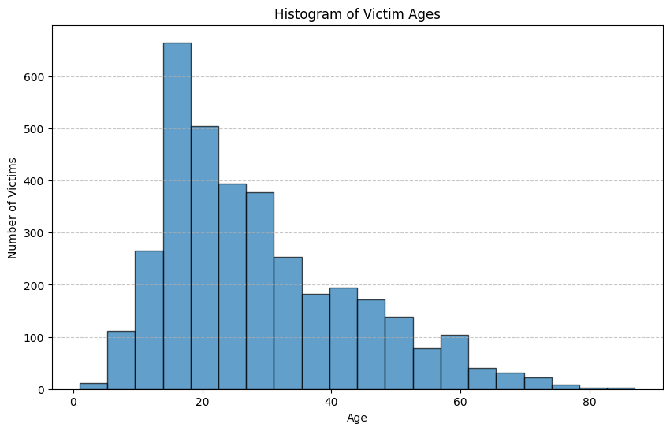

```python
# Plot histogram
plt.figure(figsize=(10, 6))
plt.hist(shark_data3['Age'], bins=20, edgecolor='black', alpha=0.7)

# Labels and title
plt.xlabel("Age")
plt.ylabel("Number of Victims")
plt.title("Histogram of Victim Ages")
plt.grid(axis='y', linestyle='--', alpha=0.7)

# Show plot
plt.show()
```

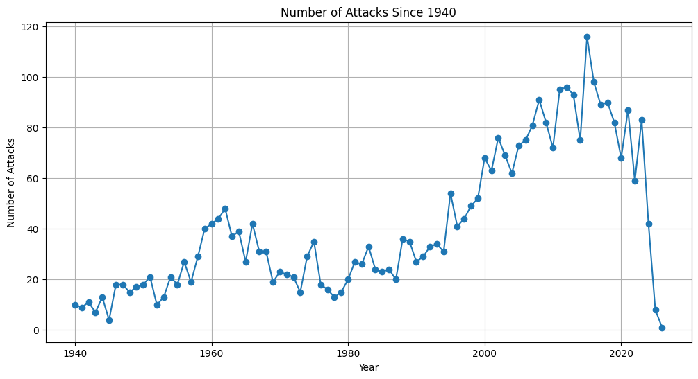

```python
import matplotlib.pyplot as plt

# Count number of attacks per year
attacks_per_year = shark_data3['year'].value_counts().sort_index()

# Plot trends
plt.figure(figsize=(12, 6))
plt.plot(attacks_per_year.index, attacks_per_year.values, marker='o', linestyle='-')

plt.xlabel("Year")
plt.ylabel("Number of Attacks")
plt.title("Number of Attacks Since 1940")
plt.grid(True)
plt.show()
```

```python
male_victims = (shark_data2['Sex'] == 'M').sum()
print(male_victims)
victims = shark_data2['Sex'].count()
print(victims)
proportion = male_victims / (victims)
print(proportion)
```

```
5611
6413
0.8749415250272883
```

```python
shark_data3['Type'].value_counts()
```

```
Type
Unprovoked             2960
Provoked                291
Invalid                 205
Watercraft               41
Sea Disaster             38
Questionable             15
?                         1
Under investigation       1
Name: count, dtype: int64
```

```python
shark_data3['Type'] = shark_data3['Type'].replace({
    'Watercraft': 'Unprovoked',
    'Sea Disaster': 'Unprovoked',
    'Provoked': 'Provoked',
    'Questionable': 'Unknown',
    '?': 'Unknown',
    'Under investigation': 'Unknown',
})

shark_data3 = shark_data3[shark_data3['Type'] != 'Invalid']
```

```python
shark_data3['Fatal Y/N'].value_counts()
```

```
Fatal Y/N
N          2809
Y           514
UNKNOWN       9
 N            6
F             4
M             1
2017          1
Name: count, dtype: int64
```

```python
shark_data3['Fatal Y/N'] = shark_data3['Fatal Y/N'].replace({
    ' N': 'N',
})

shark_data3 = shark_data3[shark_data3['Fatal Y/N'] != 'UNKNOWN']
shark_data3 = shark_data3[shark_data3['Fatal Y/N'] != 'F']
shark_data3 = shark_data3[shark_data3['Fatal Y/N'] != 'M']
shark_data3 = shark_data3[shark_data3['Fatal Y/N'] != 2017]
```

```python
shark_data3['Fatal Y/N'].value_counts()
```

```
Fatal Y/N
N    2815
Y     514
Name: count, dtype: int64
```

```python
shark_data3['Type'].value_counts()
```

```
Type
Unprovoked    3028
Provoked       289
Unknown         15
Name: count, dtype: int64
```

```python
stat1 = ((shark_data3['Type'] == 'Unprovoked') & (shark_data3['Fatal Y/N'] == 'Y')).sum()
print(stat1)
answer = stat1 / 3028
print(answer)
stat2 = ((shark_data3['Type'] == 'Provoked') & (shark_data3['Fatal Y/N'] == 'Y')).sum()
print(stat2)
answer2 = stat2 / 289
print(answer2)
stat3 = ((shark_data3['Type'] == 'Unprovoked') & (shark_data3['Sex'] == 'M')).sum()
print(stat3)
answer3 = stat3 / 3028
print(answer3)
```

```
502
0.16578599735799207
8
0.02768166089965398
2517
0.8312417437252312
```

```python
fatal_men = shark_data3[(shark_data3['Sex'] == 'M') & (shark_data3['Fatal Y/N'] == 'Y')].shape[0]
total_men = shark_data3[shark_data3['Sex'] == 'M'].shape[0]

fatal_women = shark_data3[(shark_data3['Sex'] == 'F') & (shark_data3['Fatal Y/N'] == 'Y')].shape[0]
total_women = shark_data3[shark_data3['Sex'] == 'F'].shape[0]

# Calculate fatality proportions by sex
fatal_men_proportion = fatal_men / total_men if total_men > 0 else 0
fatal_women_proportion = fatal_women / total_women if total_women > 0 else 0

print(f"Fatality proportion for male victims: {fatal_men_proportion:.2%}")
print(f"Fatality proportion for female victims: {fatal_women_proportion:.2%}")
```

```
Fatality proportion for male victims: 15.48%
Fatality proportion for female victims: 14.45%
```

```python
# Split the 'Species' column into lists of words
shark_data3.rename(columns={'Species ': 'Species'}, inplace=True)
shark_data3['Species'] = shark_data3['Species'].astype(str)

# Split species names into lists of words

shark_data3['Species_split'] = shark_data3['Species'].str.lower().str.split()



white_shark_attacks = shark_data3[shark_data3['Species_split'].apply(lambda x: 'white' in [word.lower() for word in x])]
proportion_white_sharks = white_shark_attacks.shape[0] / shark_data3.shape[0]
print(f"Proportion of attacks by white sharks: {proportion_white_sharks:.2%}")
```

```
Proportion of attacks by white sharks: 13.44%
```

**Q3.** Open the "tidy_data.pdf" document in the repo, which is a paper called Tidy Data by Hadley Wickham.

1. Read the abstract. What is this paper about?
2. Read the introduction. What is the "tidy data standard" intended to accomplish?
3. Read the intro to section 2. What does this sentence mean: "Like families, tidy datasets are all alike but every messy dataset is messy in its own way." What does this sentence mean: "For a given dataset, it’s usually easy to figure out what are observations and what are variables, but it is surprisingly difficult to precisely define variables and observations in general."
4. Read Section 2.2. How does Wickham define values, variables, and observations?
5. How is "Tidy Data" defined in section 2.3?
6. Read the intro to Section 3 and Section 3.1. What are the 5 most common problems with messy datasets? Why are the data in Table 4 messy? What is "melting" a dataset?
7. Why, specifically, is table 11 messy but table 12 tidy and "molten"?
8. Read Section 6. What is the "chicken-and-egg" problem with focusing on tidy data? What does Wickham hope happens in the future with further work on the subject of data wrangling?
1. This paper is about how to formulate clean data sets, in which every variable is a column, every observation is a row, and every type of observational unit is a table. Data tidying allows for each to manipulate datasets, which can then be modeled and visualized .
2. The tidy data standard was designed to facilitate the initial exploration and analysis of the data, and to simplify the development of data analysis tools that work well together.
3. Sentence #1: This sentence means that tidy datasets all have the same structure with different numbers of each component specific to the dataset (columns, rows, tables); messy data can be messy for a variety of non-uniform reasons- missing values, formatting, etc. Sentence #2: This sentence emphasizes the idea that when column names may hold multiple meanings, it becomes harder to distinguish between observations and variables in a data set. Functional relationships are easier to describe between variables than between rows, and it is easier to make comparisons between groups of observations than between groups of columns.
4. Values are what make up a dataset, usually numbers or strings. Values belong to a variable and an observation. A variable contains all values that measure the same underlying attribute across units. An observation contains all values measured on the same unit across attributes.
5. Tidy data is defined as every variable forming a column, every observation, and each type of observational unit forming a table.
6. Five most common problems:
   1. Column headers are values, not variable names.
   2. Multiple variables are stored in one column.
   3. Variables are stored in both rows and columns.
   4. Multiple types of observational units are stored in the same table.
   5. A single observational unit is stored in multiple tables.  
      The data is messy because the column names are values, and multiple types of observational units are stored in the same table (religion and income). Melting a dataset means turning the columns into rows; melting is parameterized by a list of columns that are already variables (colvars).
7. Table 11- lots of missing values, date is split into month and year, d1, d2, d3... should all be in one column as values Table 12- columns are not values, date is now a combined column with year and month. numbers are now aligned in a column corresponding to tmax and tmin. more compact, readable, and organized.
8. The Chicken and Egg problem is that tidy data is only as useful as the tools that work with it, then tidy tools will be tied to tidy data. This means that independently changing data tools will not improve workflow. Wickham hopes that others will build on his framework to develop even better data storage strategies and better tools. He also hopes to use human factors to improve the cognitive side of data analysis and improve the ability to design appropriate tools.

**Q4.** Many important datasets contain a race variable, typically limited to a handful of values often including Black, White, Asian, Latino, and Indigenous. This question looks at data gathering efforts on this variable by the U.S. Federal government.

1. How did the most recent US Census gather data on race?
2. Why do we gather these data? What role do these kinds of data play in politics and society? Why does data quality matter?
3. Please provide a constructive criticism of how the Census was conducted: What was done well? What do you think was missing? How should future large scale surveys be adjusted to best reflect the diversity of the population? Could some of the Census' good practices be adopted more widely to gather richer and more useful data?
4. How did the Census gather data on sex and gender? Please provide a similar constructive criticism of their practices.
5. When it comes to cleaning data, what concerns do you have about protected characteristics like sex, gender, sexual identity, or race? What challenges can you imagine arising when there are missing values? What good or bad practices might people adopt, and why?
6. Suppose someone invented an algorithm to impute values for protected characteristics like race, gender, sex, or sexuality. What kinds of concerns would you have?